# Comments for MEDB 5502, Week 03

## Topics to be covered

- What you will learn
  - What is covariate imbalance?
  - Indicator variable coding
  - Mathematical model
  - Assumptions
  - Choosing your covariates

## What is a covariate?

- Variable not of direct interest
  - Relationship to outcome is already established
  - Still must be accounted for
- Examples
  - Smoking in a cancer study
  - Gestational in a neonatology study
- A covariate can be continuous or categorical

## What is covariate imbalance?

- Difference in mean value between treatment and control group
  - Often a problem in observational studies
  - Sometimes a problem in randomized studies

## Why is covariate imbalance an issue?

- Biased estimates
  - Comparing apples to oranges
- Harms study credibility

## Examples of covariate imbalance

- Age in a study of smoking and Down’s syndrome
- Smoking in a study of artillery assignment and sperm count

## Covariate imbalance versus confounding

- Covariate imbalance is simpler
- Confounder definition relies on causation arguments

## Preventing covariate imbalance

- Randomization
- Matching
- Stratification

## Adjusting for covariate imbalance

- Propensity score models
- Analysis of covariance

## Variables cannot be in the causal pathway

- Fixed at time of randomization
- Temporally preceding exposure
- Example: bottles given during a breast feeding study

## Adjusting for baseline measurements

- Baseline = measurements prior to intervention
  - Done to improve precision
  - Can use baseline as a covariate
- Change score is an alternative
  - Also known as difference in differences (DID) model
  - Possible regression to the mean

## Break #1

- What you have learned
  - What is covariate imbalance?
- What’s coming next
  - Indicator variable coding

## Traditional t-test, 1

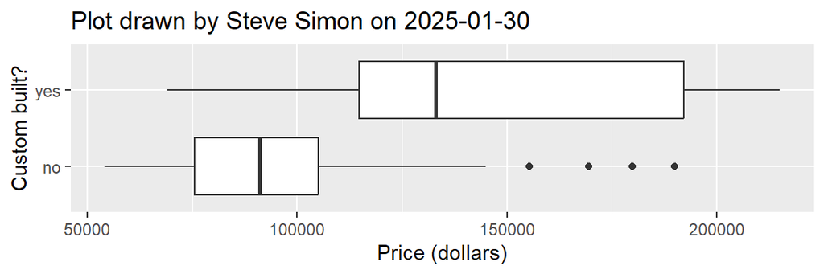

## Traditional t-test, 2

```
# A tibble: 2 × 4
  custom_build mean_price sd_price     n
  <chr>             <dbl>    <dbl> <int>
1 no               94752.   25366.    90
2 yes             144678.   47579.    27
```

## Traditional t-test, 3

```
    Two Sample t-test

data:  alb$price[alb$custom_build == "yes"] and alb$price[alb$custom_build == "no"]
t = 7.1602, df = 115, p-value = 8.159e-11
alternative hypothesis: true difference in means is not equal to 0
95 percent confidence interval:
 36114.14 63736.98
sample estimates:
mean of x mean of y
144677.78  94752.22
```

## T-test using general linear model

```
# A tibble: 2 × 5
  term            estimate std.error statistic  p.value
  <chr>              <dbl>     <dbl>     <dbl>    <dbl>
1 (Intercept)       94752.     3350.     28.3  1.26e-53
2 custom_buildyes   49926.     6973.      7.16 8.16e-11
```

```
                   2.5 %    97.5 %
(Intercept)     88117.43 101387.01
custom_buildyes 36114.14  63736.98
```

## Indicator variable coding

- Convert binary categories
  - 1 for “first” category
  - 0 for “second” category
    - Choice of “first” is arbitrary
- Can also be used for three or more categories

## Why use the general linear model?

- Works for a variety of models
  - Independent samples t-test
  - Simple linear regression
  - One factor analysis of variance
  - Multiple linear regression
  - Analysis of covariance
  - Multi-factor analysis of variance

## Why use indicator variables

- Simple interpretation
  - Average indicator is a probability
- Mix categorical and continuous independent variables

## Break #2

- What you have learned
  - Indicator variable coding
- What’s coming next
  - Mathematical model

## Mathematical model

- $Y_i=\beta_0+\beta_1 X_i+\beta_2 T_i+\epsilon_i$
  - $X_i$ is the covariate
  - $T_i$ is an indicator variable for treatment
- Estimate $\hat\beta_0,\ \hat\beta_1,\ \hat\beta_2$

## Interpretation, 1

- $\hat\beta_0$
  - estimated average value of Y
    - when X=0, T=0

## Interpretation, 2

- $\hat\beta_1$
  - estimated average change in Y
    - when X increases by one unit and
    - T is held constant

## Interpretation, 3

- $\hat\beta_2$
  - estimated average change in Y
  - when T increases by one unit and
  - X is held constant

## Interpretation, 4

- $\hat\beta_0$ is intercept for controls
- $\hat\beta_0+\hat\beta_2$ is intercept for treatment

- $\hat\beta_2$ is the adjusted average difference between the treatment and the control

## Diference in price adjusted for size

```
# A tibble: 3 × 5
  term            estimate std.error statistic  p.value
  <chr>              <dbl>     <dbl>     <dbl>    <dbl>
1 (Intercept)      11413.    6550.        1.74 8.41e- 2
2 custom_buildyes  14286.    5103.        2.80 6.01e- 3
3 sqft                55.4      4.12     13.4  3.15e-25
```

## Live demo, parts 1, 2, and 3

Refer to the [simon-5502-03-demo](https://github.com/pmean/classes/blob/master/biostats-2/03/src/simon-5502-03-demo.qmd) program.

## Break #3

- What you have learned
  - Mathematical model
- What’s coming next
  - Assumptions

## Assumptions of analysis of covariance

- Same as multiple linear regression
  - Equal variances
  - Linearity
  - Normality
- One additional assumption
  - No interaction

## Residuals versus predicted

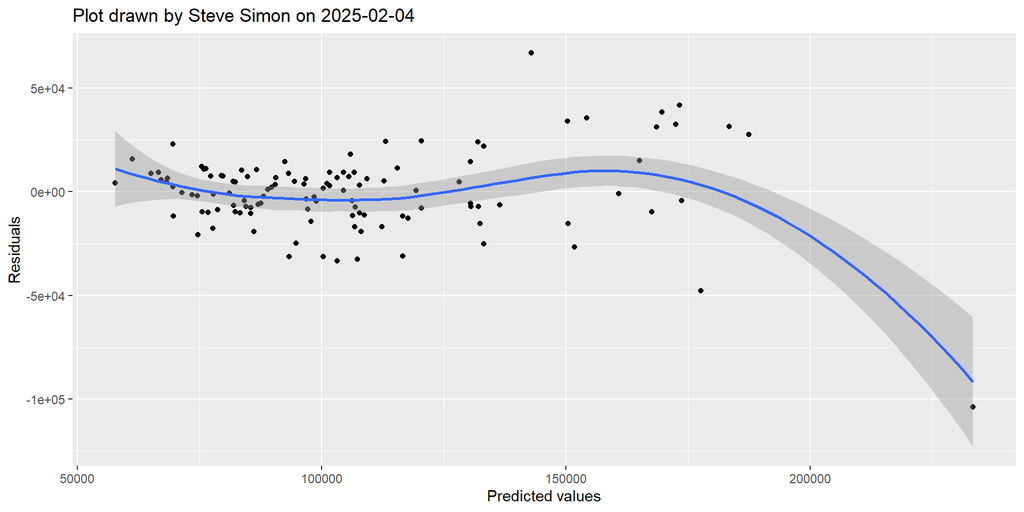

## Q-Q plot of residuals

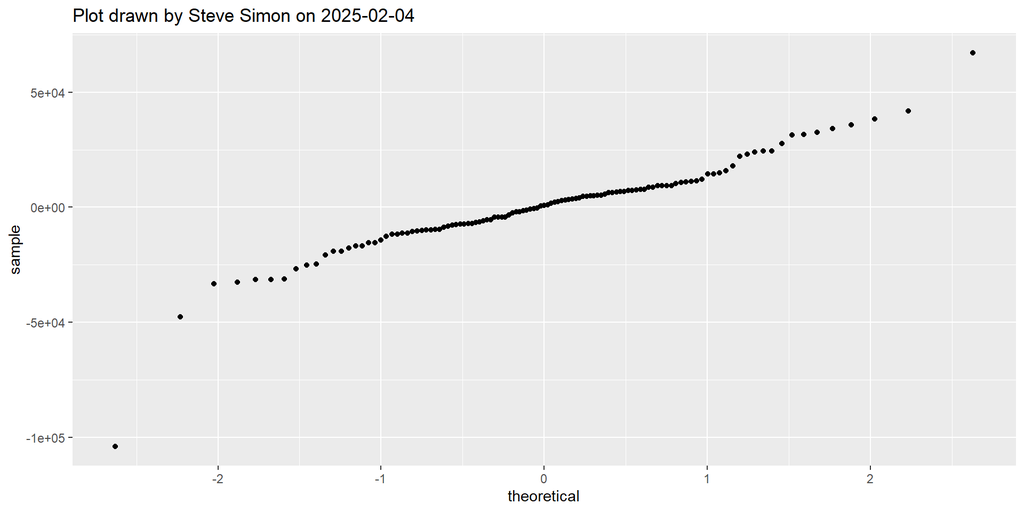

## Testing for an interaction

Save this discussion for next week

## Live demo, part 4

Refer to the simon-5502-03-demo program.

## Break #4

- What you have learned
  - Assumptions
- What’s coming next
  - Choosing your covariates

## What variable(s) should you include as covariates

- Not recommended
  - Pre-screen for imbalance
  - Pre-screen for correlation
  - Use stepwise regression
- Recommended
  - Use medical/scientific judgement
  - Be expansive

## Using matching instead of covariate adjustment

- The algorithms for matching are tricky
  - Greedy matching
- Allow a small amount of wiggle room
  - Example: age plus or minus 3 years
- Some data will be lost

## Propensity score models

- Very useful with a large number of covariates
- Logistic model of treatment/exposure versus control
  - Calculate predicted probabilities
  - Known as propensity scores
- Several ways to use propensity scores
  - Use to reweight observations
  - Use to match patients
  - Use as a single composite covariate

## Break #5

- What you have learned
  - Choosing your covariates
- What’s coming next
  - Your homework

## Summary

- What you have learned
  - What is covariate imbalance?
  - Indicator variable coding
  - Mathematical model
  - Assumptions
  - Choosing your covariates